# vildehaye sensors tutorials: Calculate Altitude by Pressure

sivan margalit

2021-10-03

## credits

This code is a translation of Sivan Toledo’s MATLAB code  
The data, contributed by Dr. Yoni Vortman and Anat Levi, of navigating study done in Hula valley at 2020

## Background

After loading Temperature and pressure measurements from vildehaye sensors, you can calculate altitude by pressure data.

For this calculation we need information about the environment barometric data on same day. We can download this information from the Israeli Meteorological Service (IMS)

Accessing to IMS data requires a Token (access key). [here a link](https://ims.gov.il/he/ObservationDataAPI) for more information.

### project structure

1. Data Folder:
   - binary data from battery and barometric sensors.
   - excel file of meteorology stations, downloaded from IMS
2. Function folder: R file with 3 local functions
3. VHsensors_calcAltitude.Rproj : R project file, define the folder, where it located, as a working folder for R project

## R Code sample

### loading libraries and local sources

The package “toolsForAtlas” contains the methods for read binary sensors data, and access to remote database by url address.

in functions folder we contains local source files contains functions, which are not in the package

```r
library(toolsForAtlas) # useful functions for atlas users
options("digits"=14)   # show long numbers till 14 digits
Sys.setlocale("LC_TIME","C")  # change local date to English names
```

```
## [1] "C"
```

```r
source("functions/pressures.R", encoding = "UTF-8")
```

### loading data from binary files

```r
# loading battery data
bat_df<-read_BAT("data/tag-972001006611-BATMON.bin")
bat_df$TAG<-"972001006611"
head(bat_df, 4)
```

```
##         TIME temp          V          TAG
## 1 1606841067   13 2.87109375 972001006611
## 2 1606841068   17 2.87109375 972001006611
## 3 1606841069   17 2.87109375 972001006611
## 4 1606841070   17 2.87109375 972001006611
```

```r
# loading barometric pressure data (in mbar units)
pressure_df<-read_BME("data/tag-972001006611-BME280.bin")
pressure_df$TAG<-"972001006611"
head(pressure_df, 4)
```

```
##         TIME  Pressure          TAG
## 1 1606841059 1006.2096 972001006611
## 2 1606841060 1006.1111 972001006611
## 3 1606841061 1006.1199 972001006611
## 4 1606841062 1006.1294 972001006611
```

### plot baromeric data

The file functions/pressures.R contains “plot_BME” function plotting barometric data. This function has 4 arguments : 1. bme.df - is the sensor’s data 2. reference.df - optional . a data frame of environment barometric data, as a reference. when this data frame is supply the function add it to the BME plot 3. fromTime - optional. if it not supply the fromTime is the minimum time in the dataframe 4. toTime - optional. if it not supply the toTime is the maximum time in the dataframe

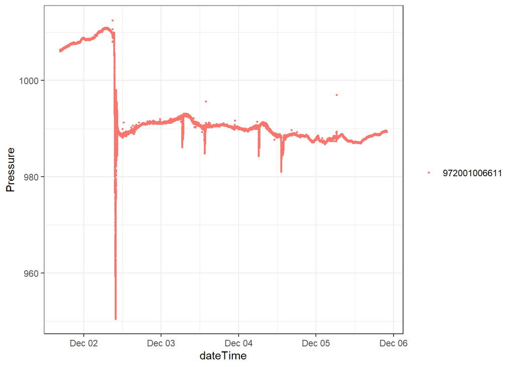

```r
bme.plot.1<-plot_BME(bme.df=pressure_df)
bme.plot.1
```

### read local meteorologic data

The file functions/pressures.R contains “get.ISM.data” function which download pressure and temperature data, from a close meteorologic station.  
In this example - it uses stattion in Har-Knaan, in Tzfat

```r
# ims.token<- Insert token from IMS, and uncomment this line
ism.lst<-get.ISM.data(easting=257000,
                      northing=780000,
                      fromTime=min(pressure_df$TIME),
                      toTime=max(pressure_df$TIME),
                      ims.token)

ism.pressure.df<-ism.lst[["pressure"]]
ism.temperatures.df<-ism.lst[["temeratures"]]
hsl<-ism.lst[["hsl"]]

print(sprintf("Station Heigh relative to sea level=%d meter",hsl))
```

```
## [1] "Station Heigh relative to sea level=936 meter"
```

```r
head(ism.pressure.df)
```

```
##                  TIME  value
## 1 2020-11-30 00:00:00 911.71
## 2 2020-11-30 00:10:00 911.67
## 3 2020-11-30 00:20:00 911.68
## 4 2020-11-30 00:30:00 911.70
## 5 2020-11-30 00:40:00 911.71
## 6 2020-11-30 00:50:00 911.62
```

```r
head(ism.temperatures.df)
```

```
##                  TIME value
## 1 2020-11-30 00:00:00  10.8
## 2 2020-11-30 00:10:00  10.8
## 3 2020-11-30 00:20:00  10.8
## 4 2020-11-30 00:30:00  10.8
## 5 2020-11-30 00:40:00  10.7
## 6 2020-11-30 00:50:00  10.5
```

(If you get red warning from red.xlsx - it is harmless) lets plot the barometric data, including the refence data, retreived from the local IMS station

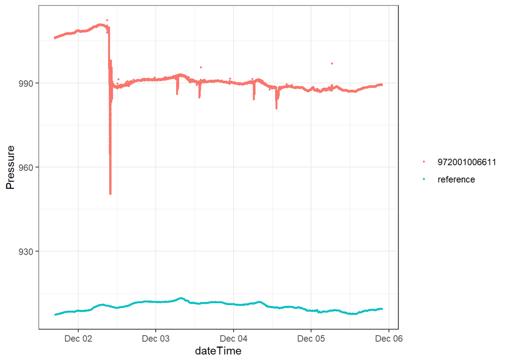

```r
bme.plot.2<-plot_BME(bme.df=pressure_df,
                     reference.df = ism.pressure.df)
bme.plot.2
```

### Estimate Altitude by pressure

1. pressure_df - is the sensor’s data
2. ism.pressure.df - a data frame of environment barometric data, as a reference.
3. refTemperature - temperature drymeasurements in IMS station.
4. refAltitude - IMS station high above sea level.

```r
alts.df<-sensorsPressureToAltitude(pressure=pressure_df,
                                   refPressure=ism.pressure.df,
                                   refTemperature=ism.temperatures.df,
                                   refAltitude=hsl)
```

now - show the altitude plot

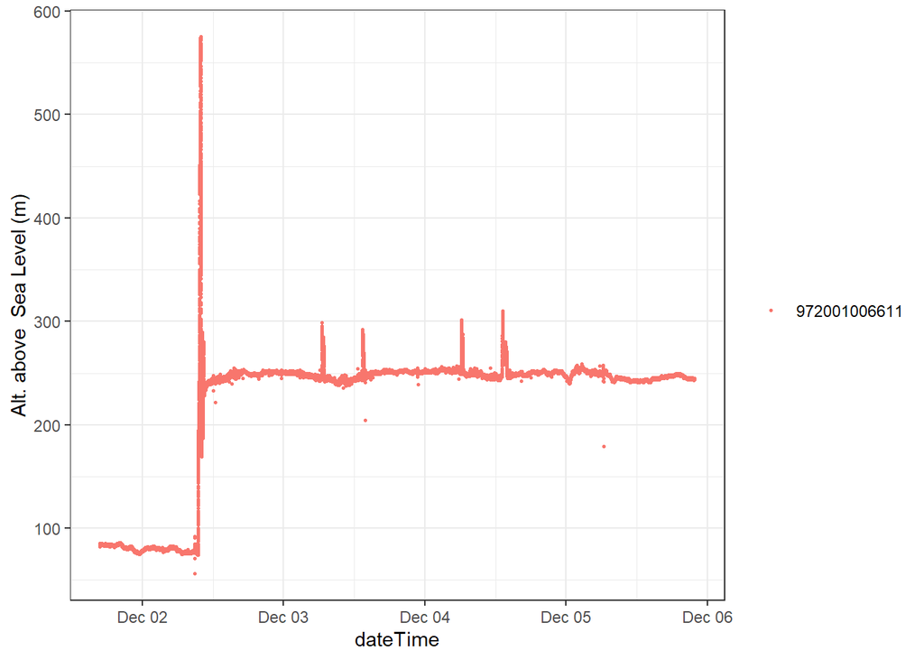

```r
alts.df$dateTime<-as.POSIXct(alts.df$TIME, tz="UTC", origin="1970-01-01")
ggplot(alts.df, aes(x=dateTime, y=alts))+
  geom_point(aes(colour = factor(TAG)), size=0.5)+
  labs(y="Alt. above  Sea Level (m)")+
  theme_bw()+
  theme(legend.title = element_blank())
```